# EDA: MTBS Wildfire Perimeters — Western US

Exploratory data analysis, pre-biomass-extraction phase

Published

May 5, 2026

```r
# =============================================================================
# SCRIPT OUTLINE
# 1. Setup — packages, paths, study parameters
# 2. MTBS data collection methodology (NBR, dNBR, per-fire calibration, severity classes)
# 3. Load, inspect, and filter MTBS data
#    3.1 Fire locations map (all fires, colored by assessment type)
#    3.2 Fires per year — all wildfires (temporal trend)
#    3.3 Assessment type summary (bar chart by category)
#    3.4 Extended assessment fires only (map)
#    3.5 Fires per year — all fires vs. extended only (side-by-side comparison)
#    3.6 Fire size distribution — all fires vs. extended only (comparison)
#    3.7 Burn severity — BSP CBI dataset description, field table, perimeter map,
#        dNBR and RdNBR distributions (all CBI plots)
# 4. GEE biomass extraction (run Python script if CSV missing)
#    4.1 Annual mean NBR over time (1984–2023)
#    4.2 Biomass before and after fire events (event-study)
#
# NOTE ON SEVERITY FIELDS:
# The MTBS perimeter shapefile contains Low_T / Mod_T / High_T as dNBR THRESHOLD
# VALUES (classification breakpoints), NOT area percentages. Per-class area
# breakdowns (% low / moderate / high) require individual fire severity rasters
# which are not included in this download. See MTBS metadata for field definitions.
# =============================================================================
```

## 1. Setup

```r
# Install any missing packages before loading
.install_if_missing <- function(pkgs) {
  missing <- pkgs[!pkgs %in% rownames(installed.packages())]
  if (length(missing) > 0) {
    message("Installing missing packages: ", paste(missing, collapse = ", "))
    install.packages(missing, repos = "https://cloud.r-project.org", quiet = TRUE)
  }
}
.install_if_missing(c("tigris", "ggspatial", "glue", "patchwork", "scales", "png"))

library(tidyverse)         # data wrangling + ggplot2
library(sf)                # spatial vector data
library(tigris)            # US Census state boundaries
library(ggspatial)         # scale bar + north arrow
library(rnaturalearth)     # fallback state boundaries (already installed)
library(here)              # project-relative paths
library(scales)            # axis formatting (comma, log)
library(lubridate)         # date parsing
library(glue)              # string interpolation
library(patchwork)         # combine plots
library(png)               # resolution check for saved figures

options(tigris_use_cache = TRUE)  # cache Census downloads locally

# Use GEOS (planar) instead of s2 (spherical) for spatial operations.
# MTBS perimeters contain self-touching edges that s2 rejects but GEOS handles
# correctly. For coterminous US data the planar approximation is fine.
sf_use_s2(FALSE)

# Anchor here() to the project root (one level up from analysis/)
here::i_am("analysis/01_mtbs_exploration.qmd")

# --- Study parameters (all hardcoded values in one place) -------------------
WESTERN_STATES <- c("AZ", "CA", "CO", "ID", "MT", "NV", "NM", "OR", "UT", "WA", "WY")
YEAR_MIN       <- 2000
YEAR_MAX       <- 2023
MIN_FIRE_ACRES <- 1000   # MTBS default minimum (fires <1000 ac are not mapped)
MTBS_PATH      <- here("data/raw/mtbs/mtbs_perimeter_data/mtbs_perims_DD.shp")

# --- Assessment type color palette (colorblind-friendly) --------------------
# Fires are colored by mapping assessment type (Initial vs Extended), since the
# perimeter shapefile has no per-class area data — only dNBR threshold values.
ASMT_COLORS <- c(
  "Initial"          = "#4393c3",
  "Initial (SS)"     = "#92c5de",
  "Extended"         = "#d6604d",
  "Extended (SS)"    = "#f4a582",
  "Emergency"        = "#878787",
  "Emergency (SS)"   = "#bababa"
)

# --- Output directory --------------------------------------------------------
dir.create(here("figures"), showWarnings = FALSE)
```

## 2. MTBS Data Collection Methodology

The Monitoring Trends in Burn Severity (MTBS) program is a joint USGS–USDA Forest Service initiative that consistently maps the location, extent, and severity of all large wildland fires in the United States from 1984 to present (Eidenshink et al., 2007). Burn severity is assessed using multitemporal Landsat satellite imagery (TM, ETM+, OLI; more recently also Sentinel-2A/2B) at 30-meter spatial resolution.

### Normalized Burn Ratio and dNBR

Burn severity is derived from the **Normalized Burn Ratio (NBR)**, which exploits the contrasting spectral response of near-infrared (NIR) and shortwave-infrared (SWIR) reflectance to fire:

$$\text{NBR} = \frac{\text{NIR} - \text{SWIR}}{\text{NIR} + \text{SWIR}}$$

Healthy, photosynthetically active vegetation produces high NIR and low SWIR reflectance, yielding a high NBR. Fire removes canopy and litter and chars the soil surface — NIR reflectance drops, SWIR rises — so post-fire NBR is lower than pre-fire NBR. The **differenced NBR (dNBR)** captures this spectral change between a pre-fire and post-fire image pair:

$$\text{dNBR} = (\text{NBR}_{\text{pre}} - \text{NBR}_{\text{post}}) \times 1000$$

The ×1000 scaling converts the dimensionless 0–1 NBR difference to integer index units (typically ranging from −500 to +1300 across fire-affected areas). **Positive dNBR = vegetation loss (burning); negative dNBR = vegetation gain (increased greenness).** These values are stored in the BSP dataset as `dnbr_val`, with the corresponding pre- and post-fire NBR in `prenbr_val` and `posnbr_val`.

### Per-Fire Threshold Calibration

A defining feature of the MTBS methodology is that **severity thresholds are calibrated separately for each fire** rather than fixed universally. For each event, an MTBS analyst selects an unburned reference area adjacent to the fire perimeter and computes the mean (`dnbr_offst`) and standard deviation (`dnbr_stddv`) of dNBR in that background region. The severity class breakpoints — `low_t` (Unburned/Low boundary), `mod_t` (Low/Moderate boundary), and `high_t` (Moderate/High boundary) — are then set relative to this per-fire background, accounting for local variation in vegetation type, pre-fire phenology, and atmospheric/sensor conditions.

This is why the threshold fields contain fire-specific index values that differ across rows and cannot be compared directly as percentages or universal cut-points. Fires with identical `high_t` values are not necessarily of the same absolute severity.

### Burn Severity Classes

Each pixel within an MTBS fire perimeter is assigned to one of five severity classes:

| Class | dNBR range | Ecological interpretation |
| --- | --- | --- |
| Increased Greenness | dNBR < 0 | Post-fire vegetation is *more* vigorous than pre-fire |
| Unburned / Low | 0 ≤ dNBR < `low_t` | No detectable spectral change or surface scorch only |
| Low | `low_t` ≤ dNBR < `mod_t` | Surface burning; little overstory damage |
| Moderate | `mod_t` ≤ dNBR < `high_t` | Mixed canopy damage; partial tree mortality |
| High | dNBR ≥ `high_t` | Near-complete canopy consumption |

**Increased Greenness** is a valid and ecologically meaningful class. It occurs when post-fire NBR exceeds pre-fire NBR — most commonly when: (1) the pre-fire image was acquired during drought or late-season senescence, and the post-fire image captured a subsequent peak-greenness flush; or (2) fire removed woody overstory and stimulated a dense herbaceous understory response. For this biomass recovery study, increased-greenness fires represent a qualitatively different treatment (stimulation, not damage) and are excluded from the primary DiD analysis.

### Assessment Types and Image Timing

The `asmnt_type` field records the timing and availability of the post-fire image used for burn severity mapping:

| Value | Definition |
| --- | --- |
| **Initial** | Post-fire imagery acquired shortly after containment |
| **Extended** | Post-fire imagery acquired during the next seasonal peak-of-green — allows vegetation to stabilize and reduces confusion between ash and low-severity burning; generally preferred for severity characte… |
| **Emergency** | Imagery acquired during the active incident; used for real-time suppression support, least reliable for severity classification |
| *(SS)* suffix | Single-scene assessment — no usable pre-fire image was available; dNBR cannot be computed; severity is based on post-fire NBR alone |

Single-scene (`SS`) assessments lack a pre-fire baseline and produce unreliable dNBR and threshold values. These are flagged and excluded from severity analyses below.

### Fire Size Thresholds and Temporal Coverage

MTBS maps fires meeting minimum size thresholds: **≥ 1,000 acres in the western United States** and ≥ 500 acres in the eastern United States (Eidenshink et al., 2007). The program covers 1984–present, anchored by the continuous Landsat 5 TM archive. This study applies the 1,000-acre threshold uniformly across the 11 Western states and restricts the analysis window to 2000–2023 to align with available biomass data.

**Note**

**Primary data reference:** Eidenshink, J., Schwind, B., Brewer, K., Zhu, Z. L., Quayle, B., & Howard, S. (2007). A project for monitoring trends in burn severity. *Fire Ecology*, 3(1), 3–21. https://www.mtbs.gov/sites/mtbs/files/inline-files/Eidenshink-final.pdf

**Dataset DOI:** https://doi.org/10.5066/P9IED7RZ

## 3. Load, Inspect, and Filter MTBS Data

```r
# Load the raw shapefile
mtbs_raw <- st_read(MTBS_PATH, quiet = TRUE)

# --- Sanity checks on raw data ----------------------------------------------
# IMPORTANT: low_t / mod_t / high_t are dNBR THRESHOLD VALUES (index units),
# NOT area percentages. They define the dNBR breakpoints between severity classes
# and vary fire-by-fire based on analyst calibration. Do not compare them as if
# they were proportions of burned area.
stopifnot(
  "Missing expected fields" =
    all(c("event_id", "ig_date", "incid_type", "burnbndac",
          "low_t", "mod_t", "high_t", "dnbr_offst", "asmnt_type") %in% names(mtbs_raw))
)

# Check geometry validity and fix if needed
n_invalid <- sum(!st_is_valid(mtbs_raw))
if (n_invalid > 0) {
  message(glue::glue("Fixing {n_invalid} invalid geometries with st_make_valid()"))
  mtbs_raw <- st_make_valid(mtbs_raw)
}

cat("Records loaded:   ", nrow(mtbs_raw), "\n")
```

```
Records loaded:    30390
```

```r
cat("Incident types:   ", paste(sort(unique(mtbs_raw$incid_type)), collapse = ", "), "\n")
```

```
Incident types:    Other, Prescribed Fire, Wildfire, Wildland Fire Use
```

```r
cat("CRS:              ", st_crs(mtbs_raw)$input, "\n")
```

```
CRS:               NAD83
```

```r
# Parse year from ig_date ("YYYY-MM-DD" character string)
# Flag fires with valid (non-sentinel) severity thresholds.
# Sentinel values -9999 and 9999 mean "No Data" per the MTBS data dictionary.
mtbs_parsed <- mtbs_raw |>
  mutate(
    year = as.integer(substr(ig_date, 1, 4)),
    # TRUE when all three threshold fields are populated with real dNBR values
    thresholds_valid = !(low_t %in% c(-9999, 9999) |
                         mod_t %in% c(-9999, 9999) |
                         high_t %in% c(-9999, 9999))
  )

cat("Year range in raw data:", min(mtbs_parsed$year, na.rm = TRUE),
    "–", max(mtbs_parsed$year, na.rm = TRUE), "\n")
```

```
Year range in raw data: 1984 – 2025
```

```r
cat("Fires with valid thresholds:", sum(mtbs_parsed$thresholds_valid),
    "/", nrow(mtbs_parsed), "\n")
```

```
Fires with valid thresholds: 9504 / 30390
```

### Filter to Study Region and Period

```r
# Download Western US state boundaries (cb = TRUE for simplified cartographic)
western_states_sf <- states(cb = TRUE, progress_bar = FALSE) |>
  filter(STUSPS %in% WESTERN_STATES) |>
  st_transform(st_crs(mtbs_parsed))   # match CRS to MTBS

cat("State boundaries loaded for:", paste(sort(western_states_sf$STUSPS), collapse = ", "), "\n")
```

```
State boundaries loaded for: AZ, CA, CO, ID, MT, NM, NV, OR, UT, WA, WY
```

```r
stopifnot("Not all 11 states returned" = nrow(western_states_sf) == 11)
```

```r
# Step 1: Wildfire only (exclude Prescribed Fire)
n_before <- nrow(mtbs_parsed)
mtbs_wf <- mtbs_parsed |> filter(incid_type == "Wildfire")
cat("After Wildfire filter:        ", nrow(mtbs_wf), "(removed", n_before - nrow(mtbs_wf), "prescribed fires)\n")
```

[output not shown]

```r
# Step 2: Year filter (2000–2023, matching biomass data availability)
mtbs_wf <- mtbs_wf |> filter(year >= YEAR_MIN & year <= YEAR_MAX)
cat("After year filter (2000–23):  ", nrow(mtbs_wf), "\n")
```

```
After year filter (2000–23):   11463
```

```r
# Step 3: Spatial intersect with 11 Western states
# Use st_join to attach state abbreviation, then drop fires outside study region
mtbs_west <- st_join(mtbs_wf, western_states_sf["STUSPS"], join = st_intersects, left = FALSE)
cat("After Western US spatial filter:", nrow(mtbs_west), "\n")
```

```
After Western US spatial filter: 6828
```

```r
# Sanity check: confirm all 11 states are represented
present_states <- sort(unique(mtbs_west$STUSPS))
missing_states  <- setdiff(WESTERN_STATES, present_states)
if (length(missing_states) > 0) {
  warning(paste("States with no fires:", paste(missing_states, collapse = ", ")))
} else {
  cat("All 11 Western states have ≥1 fire. ✓\n")
}
```

```
All 11 Western states have ≥1 fire. ✓
```

```r
# Final fire count for inline reference
n_fires_total <- nrow(mtbs_west)
cat("\nFinal dataset:", n_fires_total, "wildfires, Western US, 2000–2023\n")
```

```
Final dataset: 6828 wildfires, Western US, 2000–2023
```

```r
# ---- Sanity checks on dNBR threshold fields --------------------------------
# These checks guard against the most common misuse: treating threshold values
# (dNBR index units, typically 50–600) as if they were percentages (0–100).

valid_thresh <- mtbs_west |>
  st_drop_geometry() |>
  filter(thresholds_valid)

# Check 1: Threshold orientation.
# MTBS fires can be mapped on either axis of the dNBR spectrum:
#   "Burned" fires:             low_t < mod_t < high_t (thresholds increase toward high severity)
#   "Increased Greenness" fires: low_t > mod_t > high_t (thresholds decrease, negative dNBR)
# Both orderings are valid. What is NOT valid is a MIXED ordering (non-monotone),
# which would indicate corrupted threshold values.
valid_thresh <- valid_thresh |>
  mutate(
    thresh_orient = case_when(
      low_t < mod_t & mod_t < high_t ~ "burned",       # typical positive-dNBR fire
      low_t > mod_t & mod_t > high_t ~ "greenness",    # increased-greenness fire
      TRUE                            ~ "mixed"         # non-monotone — data problem
    )
  )

orient_tbl <- valid_thresh |> count(thresh_orient)
cat("Threshold orientation breakdown:\n")
```

```
Threshold orientation breakdown:
```

```r
print(orient_tbl)
```

```
  thresh_orient    n
1        burned 4045
2     greenness   20
```

```r
n_mixed <- sum(valid_thresh$thresh_orient == "mixed")
if (n_mixed > 0) {
  warning(sprintf("%d fires have non-monotone thresholds (low_t, mod_t, high_t not ordered) — inspect for data issues.", n_mixed))
} else {
  cat("All valid fires have monotone thresholds (burned or increased-greenness). ✓\n")
}
```

```
All valid fires have monotone thresholds (burned or increased-greenness). ✓
```

```r
# For severity distribution plots, restrict to "burned" orientation fires
# (positive dNBR axis), which is the relevant class for this biomass study.
sev_burned <- valid_thresh |> filter(thresh_orient == "burned")

# Check 2: Values must NOT all fall in 0–100 — that would mean we have percentages
# loaded into threshold fields (e.g. wrong join or wrong shapefile).
stopifnot(
  "high_t values all in 0–100 range — are these percentages, not dNBR thresholds?" =
    !(all(valid_thresh$high_t >= 0 & valid_thresh$high_t <= 100)),
  "low_t values all in 0–100 range — are these percentages, not dNBR thresholds?" =
    !(all(valid_thresh$low_t >= 0 & valid_thresh$low_t <= 100))
)
cat("Threshold scale check passed (values outside 0–100 percentage range). ✓\n")
```

```
Threshold scale check passed (values outside 0–100 percentage range). ✓
```

```r
# Check 3: Non-zero variance — if all fires had identical thresholds it would
# suggest a bad join, a constant-filled field, or the wrong column entirely.
stopifnot(
  "high_t has zero variance — all fires have same threshold (wrong field?)" =
    sd(valid_thresh$high_t, na.rm = TRUE) > 0
)
cat("Threshold variance check passed. ✓\n")
```

```
Threshold variance check passed. ✓
```

```r
# Report no-data counts and value ranges
n_nodata <- sum(!mtbs_west$thresholds_valid, na.rm = TRUE)
cat("\nFires with no-data thresholds (-9999 or 9999):", n_nodata,
    sprintf("(%.1f%%)\n", 100 * n_nodata / nrow(mtbs_west)))
```

```
Fires with no-data thresholds (-9999 or 9999): 2763 (40.5%)
```

```r
cat("\ndNBR threshold value ranges (valid fires only):\n")
```

```
dNBR threshold value ranges (valid fires only):
```

```r
cat("  High_T:", range(valid_thresh$high_t), "\n")
```

```
  High_T: -340 980
```

```r
cat("  Mod_T: ", range(valid_thresh$mod_t),  "\n")
```

```
  Mod_T:  -220 625
```

```r
cat("  Low_T: ", range(valid_thresh$low_t),  "\n")
```

```
  Low_T:  -100 500
```

```r
# Report dNBR offset range (proxy for background spectral change)
valid_offst <- mtbs_west |> st_drop_geometry() |>
  filter(!dnbr_offst %in% c(-9999, 9999))
cat("\ndNBR offset range (valid fires):", range(valid_offst$dnbr_offst), "\n")
```

```
dNBR offset range (valid fires): NA NA
```

**Note**

**Total wildfires in study region:** 6828 fires (Western US, 2000–2023, wildfires ≥1,000 acres)

**Note on severity data:** The MTBS perimeter shapefile contains `Low_T`, `Mod_T`, and `High_T` as dNBR index threshold values — not area percentages. Per-class burn area distributions (% low / moderate / high) require individual fire severity rasters and are not available in this download.

### 3.1 Fire Locations Map

Spatial distribution of MTBS wildfire perimeters across the 11 Western states, colored by mapping assessment type. Initial assessments use imagery shortly after containment; Extended assessments use a later peak-greenness post-fire image for more accurate severity calibration. This map confirms spatial coverage and that the state filter worked correctly.

```r
# Use Albers Equal Area projection for the map display — avoids distortion
# across the latitudinal spread of the Western US
crs_albers <- 5070  # EPSG:5070 (Conus Albers Equal Area)

western_states_alb <- st_transform(western_states_sf, crs_albers)
mtbs_west_alb      <- st_transform(mtbs_west, crs_albers)

# Normalize assessment type labels to the palette keys (some may have trailing
# whitespace or alternate capitalizations in the shapefile)
mtbs_west_alb <- mtbs_west_alb |>
  mutate(asmnt_type = trimws(asmnt_type))

# Use only the assessment types actually present; fall back to grey for unknowns
present_asmnt <- sort(unique(mtbs_west_alb$asmnt_type))
cat("Assessment types present:", paste(present_asmnt, collapse = ", "), "\n")
```

```
Assessment types present: Extended, Extended (SS), Initial, Initial (SS)
```

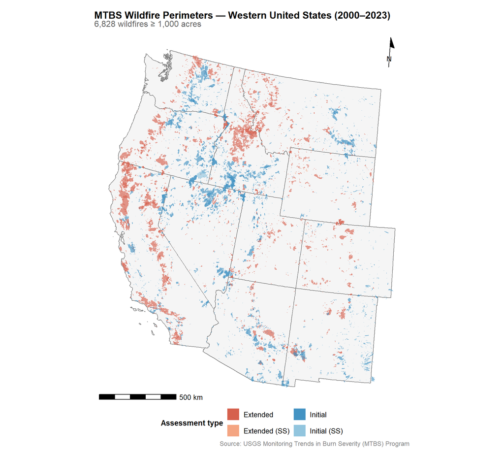

```r
p1 <- ggplot() +
  geom_sf(data = western_states_alb,
          fill = "grey96", color = "grey50", linewidth = 0.4) +
  geom_sf(data = mtbs_west_alb,
          aes(fill = asmnt_type),
          color = NA, alpha = 0.65) +
  scale_fill_manual(
    name   = "Assessment type",
    values = ASMT_COLORS,
    na.value = "#cccccc"
  ) +
  annotation_scale(location = "bl", width_hint = 0.25, text_cex = 0.85) +
  annotation_north_arrow(
    location = "tr", which_north = "true",
    style    = north_arrow_minimal(text_size = 10)
  ) +
  labs(
    title    = "MTBS Wildfire Perimeters — Western United States (2000–2023)",
    subtitle = glue::glue("{scales::comma(n_fires_total)} wildfires ≥ 1,000 acres"),
    caption  = "Source: USGS Monitoring Trends in Burn Severity (MTBS) Program"
  ) +
  theme_void(base_size = 12) +
  theme(
    plot.title      = element_text(face = "bold", size = 14),
    plot.subtitle   = element_text(color = "grey40", margin = margin(b = 6)),
    plot.caption    = element_text(color = "grey50", size = 9),
    legend.position = "bottom",
    legend.title    = element_text(size = 11, face = "bold"),
    legend.text     = element_text(size = 10),
    plot.margin     = margin(10, 10, 10, 10)
  ) +
  guides(fill = guide_legend(nrow = 2, override.aes = list(alpha = 1)))

print(p1)
```

```r
stopifnot("Plot 3.1 has no data" = nrow(mtbs_west_alb) > 0)

ggsave(here("figures/fire_locations_map.png"),
       plot = p1, width = 10, height = 9, dpi = 300, bg = "white")
img_dims <- dim(png::readPNG(here("figures/fire_locations_map.png")))
cat("Plot 3.1 saved — dimensions (px):", img_dims[2], "x", img_dims[1], "\n")
```

```
Plot 3.1 saved — dimensions (px): 3000 x 2700
```

### 3.2 Fires Per Year — All Wildfires

Annual wildfire count across the Western US, 2000–2023, with a linear trend line. This reveals whether fire frequency is increasing over time — a key consideration for the staggered DiD design (more treatment cohorts = better identification).

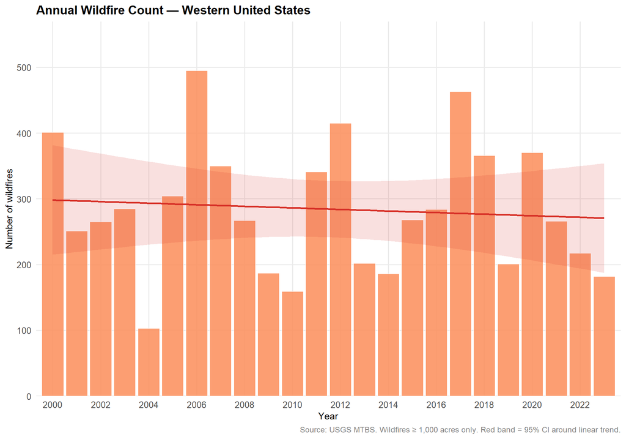

```r
fires_per_year <- mtbs_west |>
  st_drop_geometry() |>
  count(year, name = "n_fires")

expected_years <- YEAR_MIN:YEAR_MAX
missing_years  <- setdiff(expected_years, fires_per_year$year)
if (length(missing_years) > 0) {
  message("Years with zero fires (will add as 0): ", paste(missing_years, collapse = ", "))
  fires_per_year <- fires_per_year |>
    complete(year = expected_years, fill = list(n_fires = 0))
}

p2 <- ggplot(fires_per_year, aes(x = year, y = n_fires)) +
  geom_col(fill = "#fc8d59", color = "white", linewidth = 0.3, alpha = 0.85) +
  geom_smooth(method = "lm", se = TRUE,
              color = "#d73027", fill = "#d73027", alpha = 0.15, linewidth = 1) +
  scale_x_continuous(breaks = seq(YEAR_MIN, YEAR_MAX, by = 2), expand = c(0.01, 0)) +
  scale_y_continuous(labels = comma, expand = c(0, 0),
                     limits = c(0, max(fires_per_year$n_fires) * 1.15)) +
  labs(
    title   = "Annual Wildfire Count — Western United States",
    x       = "Year",
    y       = "Number of wildfires",
    caption = "Source: USGS MTBS. Wildfires ≥ 1,000 acres only. Red band = 95% CI around linear trend."
  ) +
  theme_minimal(base_size = 12) +
  theme(
    plot.title       = element_text(face = "bold", size = 14),
    plot.caption     = element_text(color = "grey50", size = 9),
    panel.grid.minor = element_blank(),
    axis.title       = element_text(size = 11),
    axis.text        = element_text(size = 10)
  )

print(p2)
```

```r
stopifnot("Y-axis must not be all zeros" = max(fires_per_year$n_fires) > 0)
stopifnot("X-axis must span 2000-2023"   = range(fires_per_year$year) == c(YEAR_MIN, YEAR_MAX))

ggsave(here("figures/fires_per_year.png"),
       plot = p2, width = 10, height = 6, dpi = 300, bg = "white")
img_dims <- dim(png::readPNG(here("figures/fires_per_year.png")))
cat("Plot 3.2 saved — dimensions (px):", img_dims[2], "x", img_dims[1], "\n")
```

```
Plot 3.2 saved — dimensions (px): 3000 x 1800
```

### 3.3 Assessment Type Summary

Count of fires in each MTBS assessment type category. Extended imagery is acquired at seasonal peak-of-green and gives the most reliable dNBR signal; SS (single-scene) variants lack a pre-fire image entirely and produce unreliable severity thresholds.

```r
asmnt_summary <- mtbs_west |>
  st_drop_geometry() |>
  mutate(asmnt_type = trimws(asmnt_type)) |>
  count(asmnt_type, name = "n_fires") |>
  arrange(desc(n_fires)) |>
  mutate(asmnt_type = factor(asmnt_type, levels = asmnt_type))

cat("Assessment type breakdown:\n")
```

```
Assessment type breakdown:
```

```r
print(asmnt_summary)
```

```
     asmnt_type n_fires
1       Initial    3842
2      Extended    2737
3  Initial (SS)     238
4 Extended (SS)      11
```

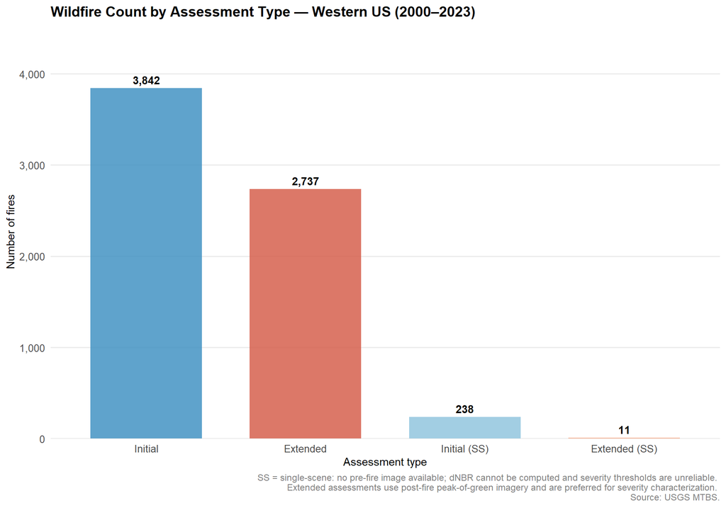

```r
p1b <- ggplot(asmnt_summary, aes(x = asmnt_type, y = n_fires, fill = asmnt_type)) +
  geom_col(alpha = 0.85, width = 0.7) +
  geom_text(aes(label = scales::comma(n_fires)),
            vjust = -0.5, size = 3.8, fontface = "bold") +
  scale_fill_manual(values = ASMT_COLORS, na.value = "#cccccc", guide = "none") +
  scale_y_continuous(labels = comma, expand = c(0, 0),
                     limits = c(0, max(asmnt_summary$n_fires) * 1.18)) +
  labs(
    title   = "Wildfire Count by Assessment Type — Western US (2000–2023)",
    x       = "Assessment type",
    y       = "Number of fires",
    caption = paste(
      "SS = single-scene: no pre-fire image available; dNBR cannot be computed and severity thresholds are unreliable.",
      "\nExtended assessments use post-fire peak-of-green imagery and are preferred for severity characterization.",
      "\nSource: USGS MTBS."
    )
  ) +
  theme_minimal(base_size = 12) +
  theme(
    plot.title         = element_text(face = "bold", size = 14),
    plot.caption       = element_text(color = "grey50", size = 9),
    panel.grid.minor   = element_blank(),
    panel.grid.major.x = element_blank(),
    axis.title         = element_text(size = 11),
    axis.text.x        = element_text(size = 10),
    axis.text.y        = element_text(size = 10)
  )

print(p1b)
```

```r
ggsave(here("figures/asmnt_type_summary.png"),
       plot = p1b, width = 9, height = 6, dpi = 300, bg = "white")
img_dims <- dim(png::readPNG(here("figures/asmnt_type_summary.png")))
cat("Plot 3.3 saved — dimensions (px):", img_dims[2], "x", img_dims[1], "\n")
```

```
Plot 3.3 saved — dimensions (px): 2700 x 1800
```

### 3.4 Extended Assessment Fires Only

Map of MTBS wildfire perimeters restricted to `asmnt_type == "Extended"` — the subset with the most reliable burn severity characterization. The subtitle reports the total count and share of all fires, making the sample-size cost of this restriction explicit.

```r
# Restrict to Extended only — exclude Extended (SS) which has no pre-fire image
mtbs_extended_alb  <- mtbs_west_alb |> filter(asmnt_type == "Extended")
mtbs_extended_west <- mtbs_west |>
  mutate(asmnt_type = trimws(asmnt_type)) |>
  filter(asmnt_type == "Extended")

n_extended   <- nrow(mtbs_extended_alb)
pct_extended <- round(100 * n_extended / n_fires_total, 1)

cat("Extended-only fires:", scales::comma(n_extended),
    glue::glue("({pct_extended}% of {scales::comma(n_fires_total)} total)\n"))
```

```
Extended-only fires: 2,737 (40.1% of 6,828 total)
```

[figure not shown]

```r
stopifnot("No Extended fires found" = n_extended > 0)

p1c <- ggplot() +
  geom_sf(data = western_states_alb,
          fill = "grey96", color = "grey50", linewidth = 0.4) +
  geom_sf(data = mtbs_extended_alb,
          fill = "#d6604d", color = NA, alpha = 0.65) +
  annotation_scale(location = "bl", width_hint = 0.25, text_cex = 0.85) +
  annotation_north_arrow(
    location = "tr", which_north = "true",
    style    = north_arrow_minimal(text_size = 10)
  ) +
  labs(
    title    = "MTBS Wildfire Perimeters — Extended Assessments Only",
    subtitle = glue::glue(
      "{scales::comma(n_extended)} wildfires ",
      "({pct_extended}% of {scales::comma(n_fires_total)} total), ",
      "Western US (2000–2023)"
    ),
    caption  = paste(
      "Extended assessments use post-fire imagery acquired at seasonal peak-of-green,",
      "providing more reliable burn severity characterization than Initial assessments.",
      "Source: USGS MTBS (Eidenshink et al., 2007)."
    )
  ) +
  theme_void(base_size = 12) +
  theme(
    plot.title    = element_text(face = "bold", size = 14),
    plot.subtitle = element_text(color = "grey40", margin = margin(b = 6)),
    plot.caption  = element_text(color = "grey50", size = 9),
    plot.margin   = margin(10, 10, 10, 10)
  )

print(p1c)
```

```r
ggsave(here("figures/fire_locations_extended_only.png"),
       plot = p1c, width = 10, height = 9, dpi = 300, bg = "white")
img_dims <- dim(png::readPNG(here("figures/fire_locations_extended_only.png")))
cat("Plot 3.4 saved — dimensions (px):", img_dims[2], "x", img_dims[1], "\n")
```

```
Plot 3.4 saved — dimensions (px): 3000 x 2700
```

### 3.5 Fires Per Year — All Fires and Extended Only

Side-by-side comparison of annual wildfire counts for all assessments vs. Extended-only. Shared y-axis allows direct visual comparison of the temporal pattern and confirms whether restricting to Extended assessments introduces temporal bias in the study sample.

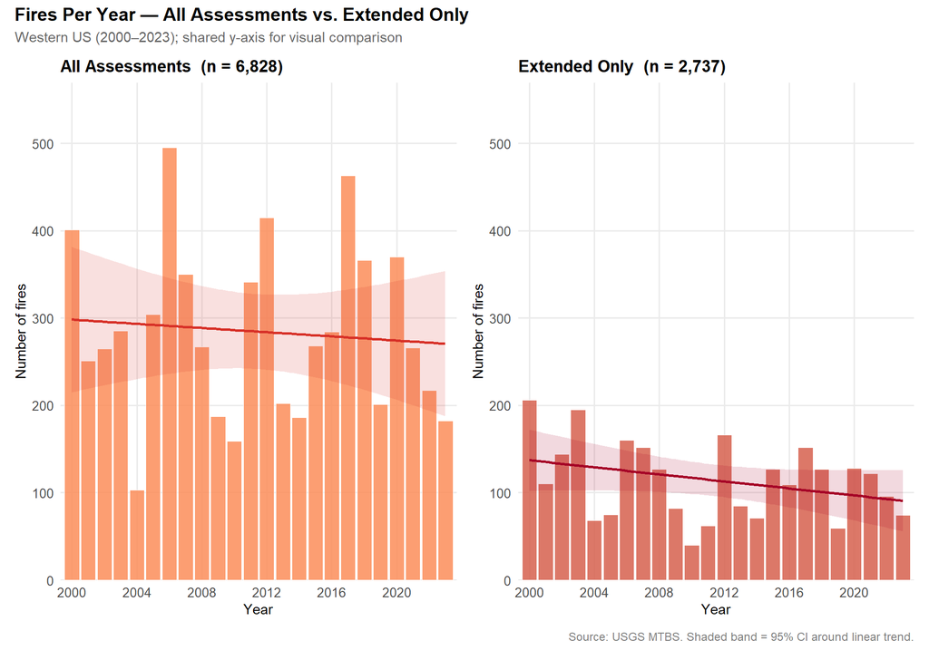

```r
fires_per_year_ext <- mtbs_extended_west |>
  st_drop_geometry() |>
  count(year, name = "n_fires") |>
  complete(year = YEAR_MIN:YEAR_MAX, fill = list(n_fires = 0))

# Shared y-axis ceiling for fair visual comparison
y_max_35 <- max(max(fires_per_year$n_fires), max(fires_per_year_ext$n_fires)) * 1.15

theme_bar <- theme_minimal(base_size = 12) +
  theme(plot.title       = element_text(face = "bold", size = 13),
        panel.grid.minor = element_blank(),
        axis.title       = element_text(size = 11),
        axis.text        = element_text(size = 10))

p35_all <- ggplot(fires_per_year, aes(x = year, y = n_fires)) +
  geom_col(fill = "#fc8d59", color = "white", linewidth = 0.3, alpha = 0.85) +
  geom_smooth(method = "lm", se = TRUE,
              color = "#d73027", fill = "#d73027", alpha = 0.15, linewidth = 1) +
  scale_x_continuous(breaks = seq(YEAR_MIN, YEAR_MAX, by = 4), expand = c(0.01, 0)) +
  scale_y_continuous(labels = comma, expand = c(0, 0), limits = c(0, y_max_35)) +
  labs(title = glue("All Assessments  (n = {scales::comma(n_fires_total)})"),
       x = "Year", y = "Number of fires") +
  theme_bar

p35_ext <- ggplot(fires_per_year_ext, aes(x = year, y = n_fires)) +
  geom_col(fill = "#d6604d", color = "white", linewidth = 0.3, alpha = 0.85) +
  geom_smooth(method = "lm", se = TRUE,
              color = "#a50026", fill = "#a50026", alpha = 0.15, linewidth = 1) +
  scale_x_continuous(breaks = seq(YEAR_MIN, YEAR_MAX, by = 4), expand = c(0.01, 0)) +
  scale_y_continuous(labels = comma, expand = c(0, 0), limits = c(0, y_max_35)) +
  labs(title = glue("Extended Only  (n = {scales::comma(n_extended)})"),
       x = "Year", y = "Number of fires") +
  theme_bar

p35 <- (p35_all | p35_ext) +
  plot_annotation(
    title    = "Fires Per Year — All Assessments vs. Extended Only",
    subtitle = glue("Western US (2000–2023); shared y-axis for visual comparison"),
    caption  = "Source: USGS MTBS. Shaded band = 95% CI around linear trend.",
    theme    = theme(
      plot.title    = element_text(face = "bold", size = 14),
      plot.subtitle = element_text(color = "grey40"),
      plot.caption  = element_text(color = "grey50", size = 9)
    )
  )

print(p35)
```

```r
ggsave(here("figures/fires_per_year_comparison.png"),
       plot = p35, width = 14, height = 6, dpi = 300, bg = "white")
img_dims <- dim(png::readPNG(here("figures/fires_per_year_comparison.png")))
cat("Plot 3.5 saved — dimensions (px):", img_dims[2], "x", img_dims[1], "\n")
```

```
Plot 3.5 saved — dimensions (px): 4200 x 1800
```

### 3.6 Fire Size Distribution

Histograms of fire sizes on a log₁₀ scale — all assessments vs. Extended only. Log scale is necessary because fire sizes span several orders of magnitude. This informs the minimum fire size threshold decision and checks whether restricting to Extended assessments biases the size distribution.

```r
size_stats <- mtbs_west |>
  st_drop_geometry() |>
  summarise(median_ac = median(burnbndac, na.rm = TRUE),
            mean_ac   = mean(burnbndac, na.rm = TRUE),
            p95_ac    = quantile(burnbndac, 0.95, na.rm = TRUE))

size_stats_ext <- mtbs_extended_west |>
  st_drop_geometry() |>
  summarise(median_ac = median(burnbndac, na.rm = TRUE),
            mean_ac   = mean(burnbndac, na.rm = TRUE),
            p95_ac    = quantile(burnbndac, 0.95, na.rm = TRUE))

cat("Fire size summary — All:\n")
```

```
Fire size summary — All:
```

```r
cat("  Median:", scales::comma(size_stats$median_ac), "ac  Mean:",
    scales::comma(round(size_stats$mean_ac)), "ac\n")
```

```
  Median: 3,546 ac  Mean: 13,670 ac
```

```r
cat("Fire size summary — Extended only:\n")
```

```
Fire size summary — Extended only:
```

```r
cat("  Median:", scales::comma(size_stats_ext$median_ac), "ac  Mean:",
    scales::comma(round(size_stats_ext$mean_ac)), "ac\n")
```

```
  Median: 4,605 ac  Mean: 17,230 ac
```

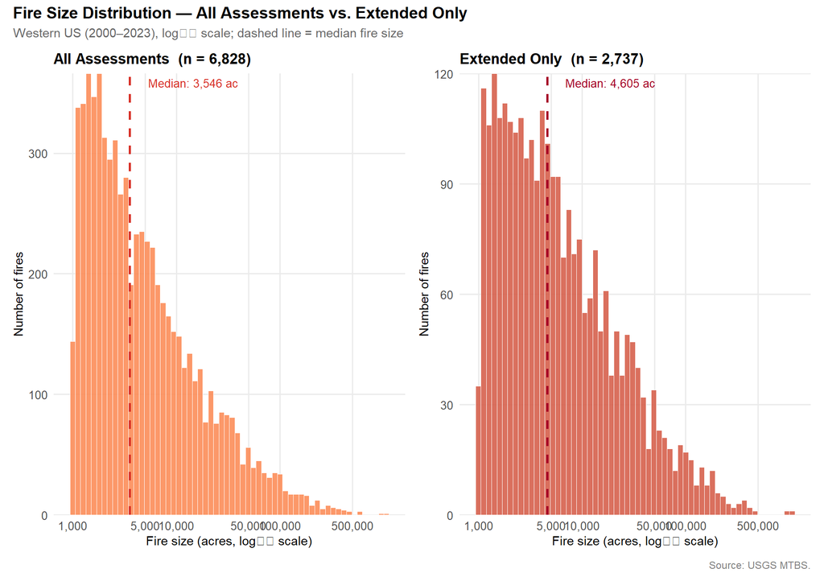

```r
n_bad <- sum(mtbs_west$burnbndac <= 0, na.rm = TRUE)
if (n_bad > 0) warning(paste(n_bad, "fires have burnbndac <= 0"))

x_breaks_size <- c(1000, 5000, 10000, 50000, 100000, 500000)

theme_hist <- theme_minimal(base_size = 12) +
  theme(plot.title       = element_text(face = "bold", size = 13),
        panel.grid.minor = element_blank(),
        axis.title       = element_text(size = 11),
        axis.text        = element_text(size = 10))

p36_all <- ggplot(mtbs_west |> st_drop_geometry(), aes(x = burnbndac)) +
  geom_histogram(bins = 60, fill = "#fc8d59", color = "white",
                 linewidth = 0.2, alpha = 0.9) +
  geom_vline(xintercept = size_stats$median_ac,
             color = "#d73027", linewidth = 1, linetype = "dashed") +
  annotate("text", x = size_stats$median_ac * 1.5, y = Inf,
           vjust = 1.5, hjust = 0, size = 3.5, color = "#d73027",
           label = paste0("Median: ", scales::comma(size_stats$median_ac), " ac")) +
  scale_x_log10(labels = label_comma(), breaks = x_breaks_size) +
  scale_y_continuous(labels = comma, expand = c(0, 0)) +
  labs(title = glue("All Assessments  (n = {scales::comma(n_fires_total)})"),
       x = "Fire size (acres, log₁₀ scale)", y = "Number of fires") +
  theme_hist

p36_ext <- ggplot(mtbs_extended_west |> st_drop_geometry(), aes(x = burnbndac)) +
  geom_histogram(bins = 60, fill = "#d6604d", color = "white",
                 linewidth = 0.2, alpha = 0.9) +
  geom_vline(xintercept = size_stats_ext$median_ac,
             color = "#a50026", linewidth = 1, linetype = "dashed") +
  annotate("text", x = size_stats_ext$median_ac * 1.5, y = Inf,
           vjust = 1.5, hjust = 0, size = 3.5, color = "#a50026",
           label = paste0("Median: ", scales::comma(size_stats_ext$median_ac), " ac")) +
  scale_x_log10(labels = label_comma(), breaks = x_breaks_size) +
  scale_y_continuous(labels = comma, expand = c(0, 0)) +
  labs(title = glue("Extended Only  (n = {scales::comma(n_extended)})"),
       x = "Fire size (acres, log₁₀ scale)", y = "Number of fires") +
  theme_hist

p36 <- (p36_all | p36_ext) +
  plot_annotation(
    title    = "Fire Size Distribution — All Assessments vs. Extended Only",
    subtitle = "Western US (2000–2023), log₁₀ scale; dashed line = median fire size",
    caption  = "Source: USGS MTBS.",
    theme    = theme(
      plot.title    = element_text(face = "bold", size = 14),
      plot.subtitle = element_text(color = "grey40"),
      plot.caption  = element_text(color = "grey50", size = 9)
    )
  )

print(p36)
```

```r
ggsave(here("figures/fire_size_comparison.png"),
       plot = p36, width = 14, height = 6, dpi = 300, bg = "white")
img_dims <- dim(png::readPNG(here("figures/fire_size_comparison.png")))
cat("Plot 3.6 saved — dimensions (px):", img_dims[2], "x", img_dims[1], "\n")
```

```
Plot 3.6 saved — dimensions (px): 4200 x 1800
```

### 3.7 Burn Severity — dNBR and RdNBR

#### About the BSP CBI Dataset

The burn severity data in this section comes from the **USGS Burn Severity Program (BSP)** perimeter shapefile at `data/raw/mtbs/burn_severity_perimeter_data/bsp_perims_DD.shp`. This file is part of the same USGS download package as the MTBS data but is a distinct, larger file: it collects fire perimeters mapped under **multiple sub-programs**, identified by the `map_prog` field. Filtering to `map_prog == "CBI"` selects fires where field crews deployed to conduct **Composite Burn Index (CBI) assessments** — the ground-validated subset of the BSP database.

CBI is a standardized field protocol in which trained observers rate burn effects across five vegetation strata (substrate and litter, herbs and low shrubs, tall shrubs and small trees, intermediate trees, large trees) on a 0–3 continuous scale at 30m plots inside the fire perimeter. An overall CBI score is a weighted average across strata. These fires are chosen for ground assessment when satellite imagery alone is insufficient or when ongoing research requires field validation.

#### How BSP CBI Perimeters Differ from MTBS

The BSP CBI perimeters are **not the same fires** as the MTBS perimeters used in sections 3.1–3.6:

| Feature | MTBS | BSP CBI (`map_prog == "CBI"`) |
| --- | --- | --- |
| Fire count | ~30,390 (1984–present) | CBI-assessed subset of BSP’s ~52,741 total fires |
| Minimum size | ≥ 1,000 ac (West), ≥ 500 ac (East) | No fixed threshold — smaller fires included |
| Assessment method | Satellite only (Landsat / Sentinel dNBR) | Satellite + CBI ground plots |
| Severity fields | dNBR threshold values (`low_t`, `mod_t`, `high_t`) | Actual spectral values (`dnbr_val`, `prenbr_val`, `posnbr_val`) |
| Event ID match with MTBS | — | Largely non-overlapping; joining on `event_id` returns near-zero matches |
| Temporal span | 1984–present | ~1994–2017 (field crew deployment period) |

Because the fire sets are largely separate, restricting BSP CBI fires to those with Extended MTBS assessments (by `event_id` join) would return near-empty results — the Extended/Initial distinction is a satellite image-timing concept that does not transfer to CBI field data.

#### BSP CBI Field Definitions

Key fields after `names(bsp_raw) <- tolower(names(bsp_raw))`:

| Field | Description |
| --- | --- |
| `event_id` | Unique fire ID: state code + centroid lat/lon (3 decimal places) + ignition date (YYYYMMDD) |
| `incid_name` | Fire incident name (“UNNAMED” if not on record) |
| `incid_type` | Incident type: Wildfire, Prescribed Fire, Wildland Fire Use, Unknown |
| `map_prog` | Mapping protocol. `"CBI"` = fires with CBI ground assessment; others include MTBS, RAVG, BAER, NPS |
| `asmnt_type` | Satellite assessment timing: Initial, Extended, Emergency; (SS) = no pre-fire image |
| `ig_date` | Ignition date (YYYY-MM-DD) |
| `burnbndac` | Perimeter area in acres |
| `dnbr_offst` | Mean dNBR in the unburned reference area — the per-fire background offset. Sentinel ±9999 = no data. |
| `dnbr_stddv` | Standard deviation of dNBR in the unburned reference area |
| `low_t` / `mod_t` / `high_t` | Per-fire dNBR thresholds for severity class boundaries (same calibration protocol as MTBS) |
| `dnbr_val` | **Actual dNBR value** for the fire — the raw severity signal, distinct from the threshold fields above |
| `prenbr_val` | **Pre-fire NBR × 1000** — vegetation density before the fire. Records with `\|prenbr_val\| ≤ 10` are excluded to prevent near-zero division in RdNBR. |
| `posnbr_val` | **Post-fire NBR × 1000** — vegetation state after fire; `dnbr_val ≈ prenbr_val − posnbr_val` |

```r
BSP_PATH <- here("data/raw/mtbs/burn_severity_perimeter_data/bsp_perims_DD.shp")

bsp_raw <- st_read(BSP_PATH, quiet = TRUE)
names(bsp_raw) <- tolower(names(bsp_raw))

# Keep only CBI field plots with valid dNBR and pre-fire NBR.
# Exclude sentinel 9999 (no data) and |preNBR| ≤ 10 (avoids RdNBR blow-up
# from near-zero pre-fire NBR in bare/sparse areas).
cbi_raw <- bsp_raw |>
  filter(
    map_prog   == "CBI",
    !is.na(dnbr_val),  !is.na(prenbr_val),
    dnbr_val   != 9999, prenbr_val != 9999,
    abs(prenbr_val) > 10
  ) |>
  mutate(rdnbr = dnbr_val / sqrt(abs(prenbr_val / 1000)))

# Spatial filter to Western US
cbi_raw  <- st_transform(cbi_raw, st_crs(western_states_sf))
cbi_west <- st_filter(cbi_raw, western_states_sf)

cat("CBI geometry type:            ", as.character(unique(st_geometry_type(cbi_west))), "\n")
```

```
CBI geometry type:             MULTIPOLYGON
```

```r
cat("CBI field plots — Western US:", nrow(cbi_west), "\n")
```

```
CBI field plots — Western US: 4777
```

```r
cat("dNBR  range:", range(cbi_west$dnbr_val),                      "\n")
```

```
dNBR  range: -340 1040
```

```r
cat("RdNBR range:", round(range(cbi_west$rdnbr, na.rm = TRUE), 1), "\n")
```

```
RdNBR range: -1189.5 3556.4
```

```r
stopifnot("No CBI plots in Western US" = nrow(cbi_west) > 0)
stopifnot("All dNBR values identical"  = sd(cbi_west$dnbr_val) > 0)
n_rdnbr_na <- sum(is.na(cbi_west$rdnbr) | !is.finite(cbi_west$rdnbr))
if (n_rdnbr_na > 0)
  message(n_rdnbr_na, " RdNBR values are NA/Inf (pre-fire NBR near zero)")
```

The map below shows BSP CBI fire locations (blue dots, plotted at centroids) overlaid on MTBS fire perimeters (grey), confirming that the two datasets cover largely different fires.

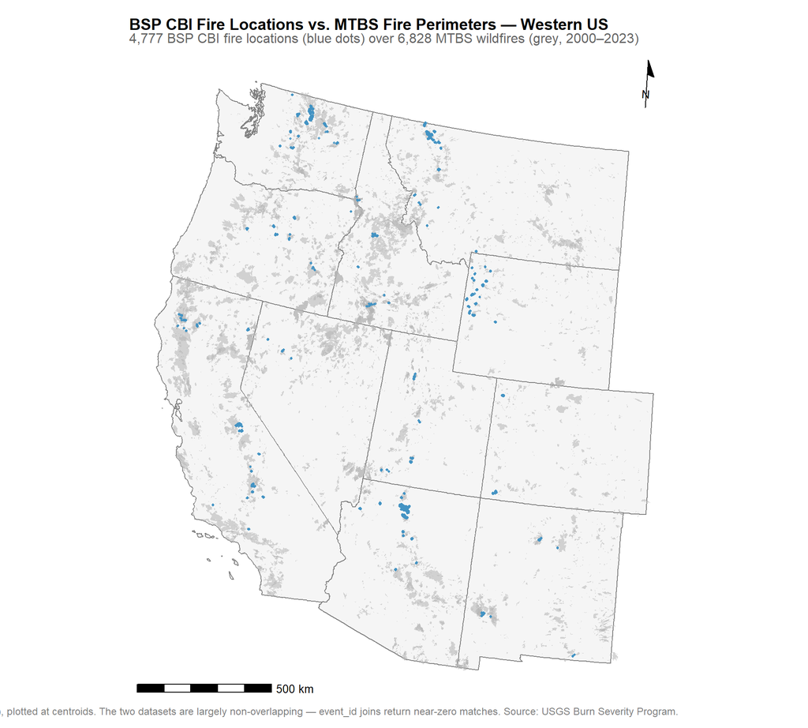

```r
# Use centroids for rendering — CBI records may be small polygons or points,
# both of which are sub-pixel at Western US scale. Centroid + color is the
# same pattern used in plot-3-7-severity-map.
bsp_cbi_pts <- cbi_west |> st_centroid() |> st_transform(crs_albers)

p_bsp <- ggplot() +
  geom_sf(data = western_states_alb,
          fill = "grey96", color = "grey50", linewidth = 0.4) +
  geom_sf(data = mtbs_west_alb,
          fill = "grey70", color = NA, alpha = 0.55) +
  geom_sf(data = bsp_cbi_pts,
          color = "#4393c3", size = 0.8, alpha = 0.8) +
  annotation_scale(location = "bl", width_hint = 0.25, text_cex = 0.85) +
  annotation_north_arrow(location = "tr", which_north = "true",
                         style = north_arrow_minimal(text_size = 10)) +
  labs(
    title    = "BSP CBI Fire Locations vs. MTBS Fire Perimeters — Western US",
    subtitle = glue(
      "{scales::comma(nrow(cbi_west))} BSP CBI fire locations (blue dots) over ",
      "{scales::comma(n_fires_total)} MTBS wildfires (grey, 2000–2023)"
    ),
    caption = paste(
      "Grey polygons = MTBS satellite-assessed wildfires (≥ 1,000 acres, Western US, 2000–2023).",
      "Blue dots = BSP fires with CBI field assessment (map_prog = 'CBI', ~1994–2017), plotted at centroids.",
      "The two datasets are largely non-overlapping — event_id joins return near-zero matches.",
      "Source: USGS Burn Severity Program."
    )
  ) +
  theme_void(base_size = 12) +
  theme(
    plot.title    = element_text(face = "bold", size = 14),
    plot.subtitle = element_text(color = "grey40", margin = margin(b = 6)),
    plot.caption  = element_text(color = "grey50", size = 9),
    plot.margin   = margin(10, 10, 10, 10)
  )

print(p_bsp)
```

```r
stopifnot("No BSP CBI locations to map" = nrow(bsp_cbi_pts) > 0)

ggsave(here("figures/bsp_cbi_perimeter_map.png"),
       plot = p_bsp, width = 10, height = 9, dpi = 300, bg = "white")
img_dims <- dim(png::readPNG(here("figures/bsp_cbi_perimeter_map.png")))
cat("BSP location map saved — dimensions (px):", img_dims[2], "x", img_dims[1], "\n")
```

```
BSP location map saved — dimensions (px): 3000 x 2700
```

#### Severity Index Distributions — dNBR and RdNBR

The spectral indices used to characterize burn severity within BSP CBI fire perimeters are derived from Landsat imagery (see **Section 2** for the full NBR derivation) and stored in the `dnbr_val` and computed `rdnbr` fields.

**dNBR** (differenced Normalized Burn Ratio) measures *absolute* spectral change caused by fire:

$$\text{dNBR} = (\text{NBR}_{\text{pre}} - \text{NBR}_{\text{post}}) \times 1000$$

Positive values indicate vegetation loss; higher values indicate more severe burning. Raw dNBR is useful within a single fire but poorly suited for cross-fire comparison because its magnitude depends on pre-fire vegetation density — a dNBR of 400 in dense old-growth represents far less relative canopy loss than 400 in sparse shrubland.

**RdNBR** (Relativized dNBR; Miller & Thode, 2007) corrects for pre-fire vegetation density:

$$\text{RdNBR} = \frac{\text{dNBR}}{\sqrt{|\text{NBR}_{\text{pre}} / 1000|}}$$

This rescaling makes severity comparable across fires and biomes and is the preferred continuous treatment variable for the cross-fire DiD analysis. Records with `|prenbr_val| ≤ 10` are excluded to avoid near-zero division.

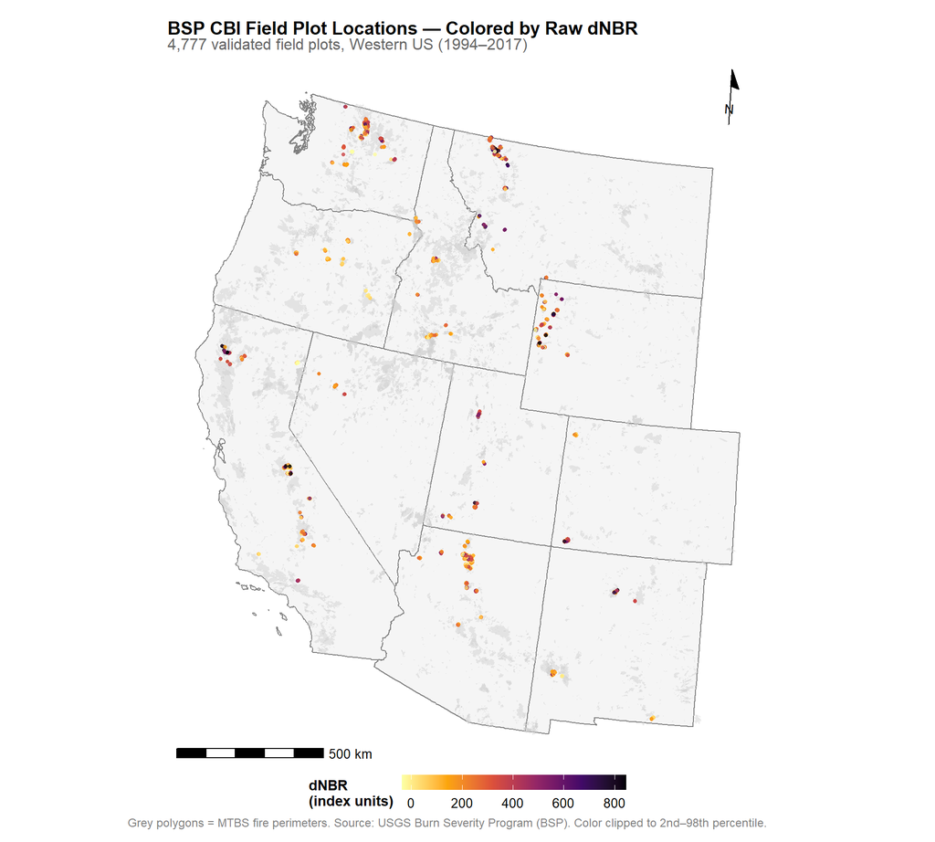

```r
# Map of all CBI field plots colored by dNBR
cbi_pts_alb <- cbi_west |>
  st_centroid() |>
  st_transform(crs_albers)

dnbr_lims <- quantile(cbi_west$dnbr_val, c(0.02, 0.98), na.rm = TRUE)

p4a <- ggplot() +
  geom_sf(data = western_states_alb,
          fill = "grey96", color = "grey50", linewidth = 0.4) +
  geom_sf(data = mtbs_west_alb,
          fill = "grey80", color = NA, alpha = 0.45) +
  geom_sf(data = cbi_pts_alb,
          aes(color = dnbr_val), size = 1.1, alpha = 0.8) +
  scale_color_viridis_c(
    name      = "dNBR\n(index units)",
    option    = "inferno", direction = -1,
    limits    = dnbr_lims, oob = scales::squish, labels = comma
  ) +
  annotation_scale(location = "bl", width_hint = 0.25, text_cex = 0.85) +
  annotation_north_arrow(location = "tr", which_north = "true",
                         style = north_arrow_minimal(text_size = 10)) +
  labs(
    title    = "BSP CBI Field Plot Locations — Colored by Raw dNBR",
    subtitle = glue("{scales::comma(nrow(cbi_west))} validated field plots, Western US (1994–2017)"),
    caption  = paste0("Grey polygons = MTBS fire perimeters. ",
                      "Source: USGS Burn Severity Program (BSP). ",
                      "Color clipped to 2nd–98th percentile.")
  ) +
  theme_void(base_size = 12) +
  theme(
    plot.title      = element_text(face = "bold", size = 14),
    plot.subtitle   = element_text(color = "grey40", margin = margin(b = 6)),
    plot.caption    = element_text(color = "grey50", size = 9),
    legend.position = "bottom",
    legend.title    = element_text(size = 11, face = "bold"),
    legend.text     = element_text(size = 10),
    plot.margin     = margin(10, 10, 10, 10)
  ) +
  guides(color = guide_colorbar(barwidth = 12, barheight = 0.8))

print(p4a)
```

```r
ggsave(here("figures/severity_dnbr_map.png"),
       plot = p4a, width = 10, height = 9, dpi = 300, bg = "white")
img_dims <- dim(png::readPNG(here("figures/severity_dnbr_map.png")))
cat("Plot 3.7 map saved — dimensions (px):", img_dims[2], "x", img_dims[1], "\n")
```

```
Plot 3.7 map saved — dimensions (px): 3000 x 2700
```

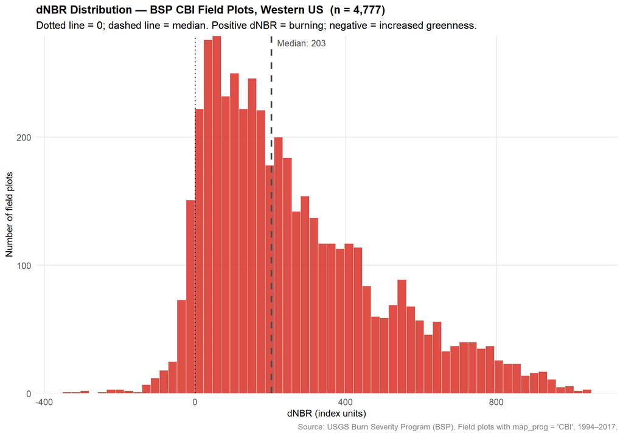

```r
rdnbr_df_all <- cbi_west |> st_drop_geometry() |> filter(is.finite(rdnbr))

dnbr_med_all <- median(cbi_west$dnbr_val, na.rm = TRUE)

theme_sev <- theme_minimal(base_size = 12) +
  theme(plot.title       = element_text(face = "bold", size = 13),
        plot.caption     = element_text(color = "grey50", size = 9),
        panel.grid.minor = element_blank(),
        axis.title       = element_text(size = 11),
        axis.text        = element_text(size = 10))

p4b <- ggplot(cbi_west |> st_drop_geometry(), aes(x = dnbr_val)) +
  geom_histogram(bins = 60, fill = "#d73027", color = "white",
                 linewidth = 0.2, alpha = 0.85) +
  geom_vline(xintercept = 0, color = "black", linewidth = 0.6, linetype = "dotted") +
  geom_vline(xintercept = dnbr_med_all, color = "#4d4d4d", linewidth = 1, linetype = "dashed") +
  annotate("text", x = dnbr_med_all + 15, y = Inf, vjust = 1.5, hjust = 0,
           size = 3.5, color = "#4d4d4d", label = paste0("Median: ", round(dnbr_med_all))) +
  scale_x_continuous(labels = comma) +
  scale_y_continuous(labels = comma, expand = c(0, 0)) +
  labs(
    title   = glue("dNBR Distribution — BSP CBI Field Plots, Western US  (n = {scales::comma(nrow(cbi_west))})"),
    subtitle = "Dotted line = 0; dashed line = median. Positive dNBR = burning; negative = increased greenness.",
    x       = "dNBR (index units)",
    y       = "Number of field plots",
    caption = "Source: USGS Burn Severity Program (BSP). Field plots with map_prog = 'CBI', 1994–2017."
  ) +
  theme_sev

print(p4b)
```

```r
stopifnot("dNBR histogram has no data" = nrow(cbi_west) > 0)

ggsave(here("figures/severity_dnbr_histogram.png"),
       plot = p4b, width = 10, height = 6, dpi = 300, bg = "white")
img_dims <- dim(png::readPNG(here("figures/severity_dnbr_histogram.png")))
cat("Plot 3.7 dNBR saved — dimensions (px):", img_dims[2], "x", img_dims[1], "\n")
```

```
Plot 3.7 dNBR saved — dimensions (px): 3000 x 1800
```

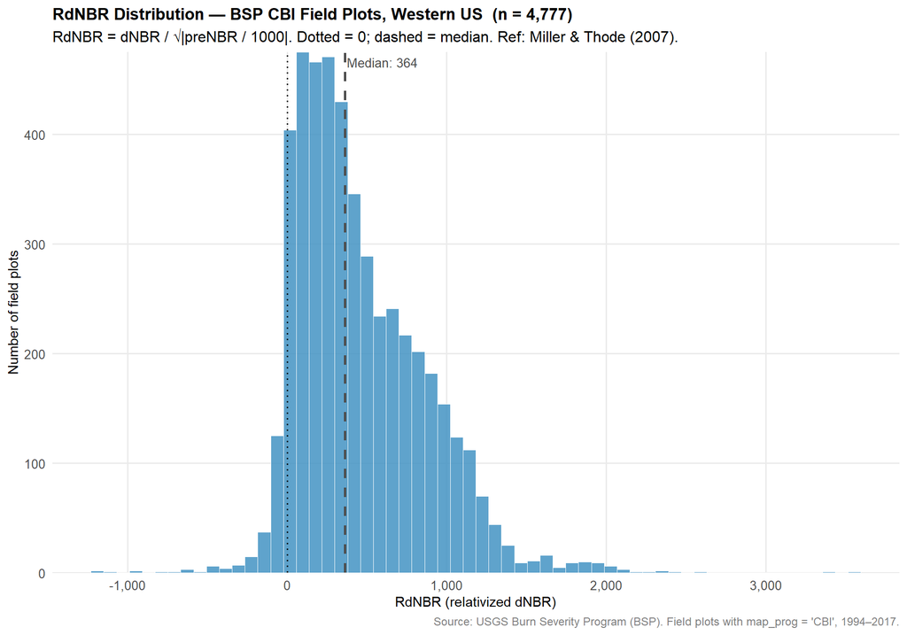

```r
rdnbr_med_all <- median(rdnbr_df_all$rdnbr, na.rm = TRUE)

p4c <- ggplot(rdnbr_df_all, aes(x = rdnbr)) +
  geom_histogram(bins = 60, fill = "#4393c3", color = "white",
                 linewidth = 0.2, alpha = 0.85) +
  geom_vline(xintercept = 0, color = "black", linewidth = 0.6, linetype = "dotted") +
  geom_vline(xintercept = rdnbr_med_all, color = "#4d4d4d", linewidth = 1, linetype = "dashed") +
  annotate("text", x = rdnbr_med_all + 10, y = Inf, vjust = 1.5, hjust = 0,
           size = 3.5, color = "#4d4d4d", label = paste0("Median: ", round(rdnbr_med_all))) +
  scale_x_continuous(labels = comma) +
  scale_y_continuous(labels = comma, expand = c(0, 0)) +
  labs(
    title    = glue("RdNBR Distribution — BSP CBI Field Plots, Western US  (n = {scales::comma(nrow(rdnbr_df_all))})"),
    subtitle = "RdNBR = dNBR / √|preNBR / 1000|. Dotted = 0; dashed = median. Ref: Miller & Thode (2007).",
    x        = "RdNBR (relativized dNBR)",
    y        = "Number of field plots",
    caption  = "Source: USGS Burn Severity Program (BSP). Field plots with map_prog = 'CBI', 1994–2017."
  ) +
  theme_sev

print(p4c)
```

```r
stopifnot("dNBR histogram has no data"  = nrow(cbi_west) > 0)
stopifnot("RdNBR histogram has no data" = nrow(rdnbr_df_all) > 0)

ggsave(here("figures/severity_rdnbr_histogram.png"),
       plot = p4c, width = 10, height = 6, dpi = 300, bg = "white")
img_dims <- dim(png::readPNG(here("figures/severity_rdnbr_histogram.png")))
cat("Plot 3.7 RdNBR saved — dimensions (px):", img_dims[2], "x", img_dims[1], "\n")
```

```
Plot 3.7 RdNBR saved — dimensions (px): 3000 x 1800
```

## Summary

```r
n_valid_thresh <- sum(mtbs_west$thresholds_valid, na.rm = TRUE)
median_dnbr    <- median(cbi_west$dnbr_val, na.rm = TRUE)
median_rdnbr   <- median(rdnbr_df_all$rdnbr, na.rm = TRUE)

summary_tbl <- tibble::tribble(
  ~Metric,                                        ~Value,
  "Total wildfires (2000–2023)",                  scales::comma(n_fires_total),
  "Extended assessment fires",                    glue("{scales::comma(n_extended)} ({pct_extended}%)"),
  "States covered",                               paste(present_states, collapse = ", "),
  "Median fire size — all",                       paste(scales::comma(size_stats$median_ac), "acres"),
  "Median fire size — Extended only",             paste(scales::comma(size_stats_ext$median_ac), "acres"),
  "Fires with valid severity thresholds",         scales::comma(n_valid_thresh),
  "CBI field plots — Western US",                 scales::comma(nrow(cbi_west)),
  "Median dNBR (CBI plots)",                      as.character(round(median_dnbr)),
  "Median RdNBR (all CBI plots)",                 as.character(round(median_rdnbr))
)

knitr::kable(summary_tbl, col.names = c("Metric", "Value"), align = "lr")
```

| Metric | Value |
| --- | --- |
| Total wildfires (2000–2023) | 6,828 |
| Extended assessment fires | 2,737 (40.1%) |
| States covered | AZ, CA, CO, ID, MT, NM, NV, OR, UT, WA, WY |
| Median fire size — all | 3,546 acres |
| Median fire size — Extended only | 4,605 acres |
| Fires with valid severity thresholds | 4,065 |
| CBI field plots — Western US | 4,777 |
| Median dNBR (CBI plots) | 203 |
| Median RdNBR (all CBI plots) | 364 |

## 4. GEE Biomass Extraction

```r
START_YEAR_BIO <- 1984
END_YEAR_BIO   <- 2023
STATE_LABEL    <- "California"
CSV_PATH       <- here("output/biomass_timeseries.csv")
PYTHON_SCRIPT  <- here("scripts/python/01_extract_biomass_gee.py")

dir.create(here("output"), showWarnings = FALSE)
```

Run the Python extraction script if the CSV has not been generated yet. Requires prior `earthengine authenticate` in a terminal.

```r
if (!file.exists(CSV_PATH)) {
  message("Biomass CSV not found — running GEE extraction for ", STATE_LABEL, "...")
  python_paths <- c(
    "C:/Users/shaht/anaconda3/python.exe",
    Sys.which("python3"),
    Sys.which("python")
  )
  python_exe <- python_paths[file.exists(python_paths)][1]
  if (is.na(python_exe)) stop("Python not found. Set the path manually in this chunk.")
  result <- system2(python_exe, args = PYTHON_SCRIPT, stdout = TRUE, stderr = TRUE)
  cat(result, sep = "\n")
  if (!file.exists(CSV_PATH)) {
    stop("Extraction did not produce output/biomass_timeseries.csv.\n",
         "Check GEE authentication and GEE_PROJECT in 01_extract_biomass_gee.py.")
  }
  message("Extraction complete.")
} else {
  message("CSV found at ", CSV_PATH, " — skipping extraction.")
}
```

```r
biomass_raw <- read_csv(CSV_PATH, show_col_types = FALSE)

stopifnot(
  "Missing expected columns" =
    all(c("event_id", "fire_year", "year", "fitted_nbr") %in% names(biomass_raw))
)
stopifnot("Year range out of bounds" =
    all(biomass_raw$year >= START_YEAR_BIO & biomass_raw$year <= END_YEAR_BIO))

n_fires_bio <- n_distinct(biomass_raw$event_id)
pct_valid   <- mean(!is.na(biomass_raw$fitted_nbr)) * 100

cat("Fires:      ", n_fires_bio, "\n")
```

```
Fires:       80
```

```r
cat("Year range: ", min(biomass_raw$year), "–", max(biomass_raw$year), "\n")
```

```
Year range:  1984 – 2023
```

```r
cat("Valid NBR:  ", round(pct_valid, 1), "%\n")
```

```
Valid NBR:   97.3 %
```

```r
if (pct_valid < 50) {
  warning("< 50% valid NBR — check date window and Landsat coverage.")
}
```

```r
# Convert from inverted NBR convention (loss = positive) to display scale
# (higher = more vegetation = more biomass)
biomass <- biomass_raw |>
  mutate(display_nbr = -fitted_nbr) |>
  filter(!is.na(display_nbr))

cat("Records retained after NA removal:", nrow(biomass), "\n")
```

```
Records retained after NA removal: 3114
```

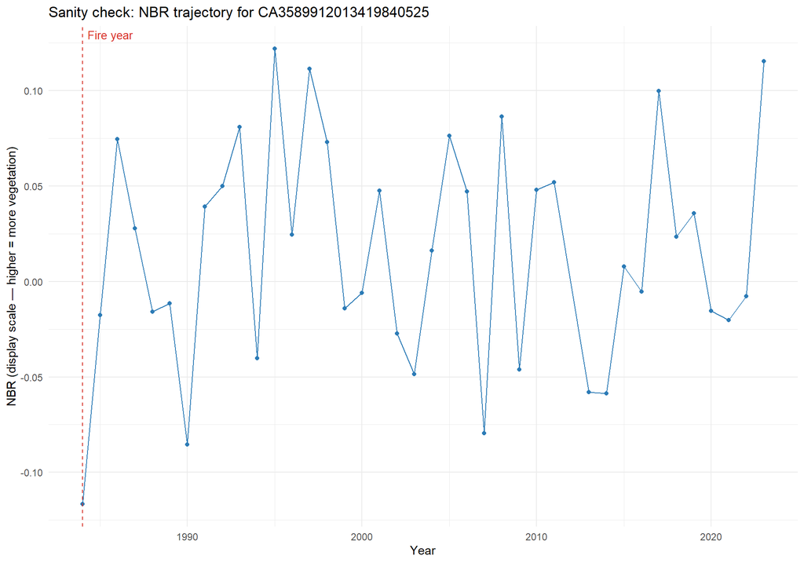

```r
# Single-fire sanity check: trajectory should show a dip at the fire year
example_fire <- biomass |>
  filter(event_id == first(unique(event_id))) |>
  arrange(year)

ggplot(example_fire, aes(x = year, y = display_nbr)) +
  geom_line(color = "#2c7bb6") +
  geom_point(color = "#2c7bb6") +
  geom_vline(xintercept = first(example_fire$fire_year),
             linetype = "dashed", color = "#d73027") +
  annotate("text", x = first(example_fire$fire_year) + 0.3, y = Inf,
           vjust = 1.5, hjust = 0, label = "Fire year",
           color = "#d73027", size = 3.5) +
  labs(title = glue("Sanity check: NBR trajectory for {first(example_fire$event_id)}"),
       x = "Year", y = "NBR (display scale — higher = more vegetation)") +
  theme_minimal(base_size = 11)
```

### 4.1 Annual Mean NBR Over Time

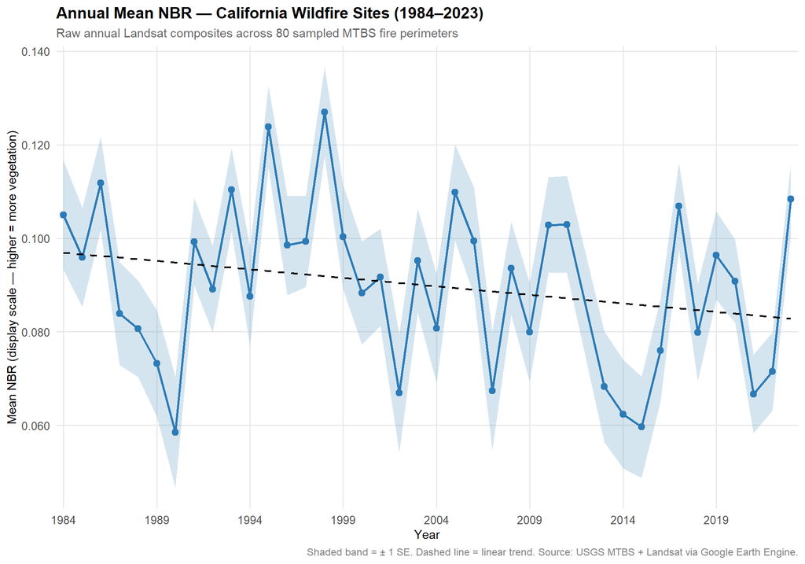

```r
annual_nbr <- biomass |>
  group_by(year) |>
  summarise(
    mean_nbr = mean(display_nbr),
    se_nbr   = sd(display_nbr) / sqrt(n()),
    n_fires  = n_distinct(event_id),
    .groups  = "drop"
  )

stopifnot("Annual NBR should not be all NA" = !all(is.na(annual_nbr$mean_nbr)))

p5 <- ggplot(annual_nbr, aes(x = year, y = mean_nbr)) +
  geom_ribbon(aes(ymin = mean_nbr - se_nbr, ymax = mean_nbr + se_nbr),
              fill = "#2c7bb6", alpha = 0.2) +
  geom_line(color = "#2c7bb6", linewidth = 1) +
  geom_point(color = "#2c7bb6", size = 2.5) +
  geom_smooth(method = "lm", se = FALSE,
              color = "black", linetype = "dashed", linewidth = 0.8) +
  scale_x_continuous(breaks = seq(START_YEAR_BIO, END_YEAR_BIO, by = 5),
                     expand = c(0.01, 0)) +
  scale_y_continuous(labels = number_format(accuracy = 0.001)) +
  labs(
    title    = glue("Annual Mean NBR — {STATE_LABEL} Wildfire Sites ({START_YEAR_BIO}–{END_YEAR_BIO})"),
    subtitle = glue("Raw annual Landsat composites across {n_fires_bio} sampled MTBS fire perimeters"),
    x        = "Year",
    y        = "Mean NBR (display scale — higher = more vegetation)",
    caption  = "Shaded band = ± 1 SE. Dashed line = linear trend. Source: USGS MTBS + Landsat via Google Earth Engine."
  ) +
  theme_minimal(base_size = 12) +
  theme(
    plot.title       = element_text(face = "bold", size = 14),
    plot.subtitle    = element_text(color = "grey40", size = 11),
    plot.caption     = element_text(color = "grey50", size = 9),
    panel.grid.minor = element_blank(),
    axis.title       = element_text(size = 11),
    axis.text        = element_text(size = 10)
  )

print(p5)
```

```r
stopifnot("Y-axis is all zero — check NBR sign" = !all(annual_nbr$mean_nbr == 0))

ggsave(here("figures/biomass_trend_over_time.png"),
       plot = p5, width = 10, height = 6, dpi = 300, bg = "white")
img_dims <- dim(png::readPNG(here("figures/biomass_trend_over_time.png")))
cat("Plot 4.1 saved — dimensions (px):", img_dims[2], "x", img_dims[1], "\n")
```

```
Plot 4.1 saved — dimensions (px): 3000 x 1800
```

### 4.2 Biomass Before and After Fire Events

```r
biomass_event <- biomass |>
  mutate(rel_year = year - fire_year) |>
  filter(rel_year >= -5, rel_year <= 10)

event_mean <- biomass_event |>
  group_by(rel_year) |>
  summarise(
    mean_nbr = mean(display_nbr),
    se_nbr   = sd(display_nbr) / sqrt(n()),
    n_fires  = n_distinct(event_id),
    .groups  = "drop"
  )

cat("Fires contributing at rel_year =  0:", event_mean$n_fires[event_mean$rel_year == 0],  "\n")
```

```
Fires contributing at rel_year =  0: 78
```

```r
cat("Fires contributing at rel_year = -5:", event_mean$n_fires[event_mean$rel_year == -5], "\n")
```

```
Fires contributing at rel_year = -5: 67
```

```r
cat("Fires contributing at rel_year = +10:", event_mean$n_fires[event_mean$rel_year == 10], "\n")
```

```
Fires contributing at rel_year = +10: 58
```

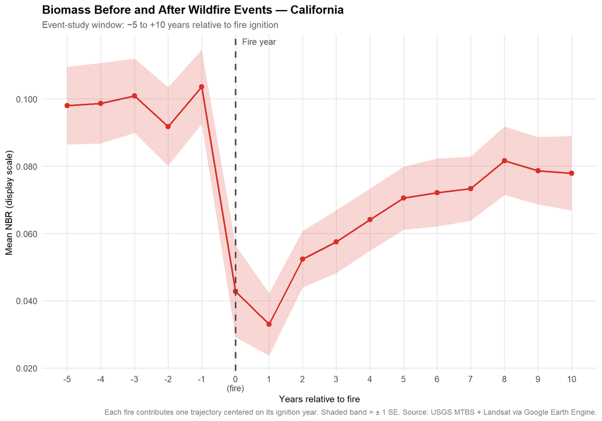

```r
p6 <- ggplot(event_mean, aes(x = rel_year, y = mean_nbr)) +
  geom_ribbon(aes(ymin = mean_nbr - se_nbr, ymax = mean_nbr + se_nbr),
              fill = "#d73027", alpha = 0.2) +
  geom_line(color = "#d73027", linewidth = 1) +
  geom_point(color = "#d73027", size = 2.5) +
  geom_vline(xintercept = 0, linetype = "dashed", linewidth = 0.9, color = "grey30") +
  annotate("text", x = 0.2, y = Inf, vjust = 1.5, hjust = 0,
           label = "Fire year", color = "grey30", size = 3.5) +
  scale_x_continuous(
    breaks = -5:10,
    labels = function(x) ifelse(x == 0, "0\n(fire)", as.character(x))
  ) +
  scale_y_continuous(labels = number_format(accuracy = 0.001)) +
  labs(
    title    = glue("Biomass Before and After Wildfire Events — {STATE_LABEL}"),
    subtitle = "Event-study window: −5 to +10 years relative to fire ignition",
    x        = "Years relative to fire",
    y        = "Mean NBR (display scale)",
    caption  = "Each fire contributes one trajectory centered on its ignition year. Shaded band = ± 1 SE. Source: USGS MTBS + Landsat via Google Earth Engine."
  ) +
  theme_minimal(base_size = 12) +
  theme(
    plot.title       = element_text(face = "bold", size = 14),
    plot.subtitle    = element_text(color = "grey40", size = 11),
    plot.caption     = element_text(color = "grey50", size = 9),
    panel.grid.minor = element_blank(),
    axis.title       = element_text(size = 11),
    axis.text        = element_text(size = 10)
  )

print(p6)
```

```r
stopifnot("Year 0 must have data" = 0 %in% event_mean$rel_year)
stopifnot("CI should not be wider than ± 0.5 NBR" =
    all(event_mean$se_nbr < 0.5, na.rm = TRUE))

ggsave(here("figures/biomass_before_after_fire.png"),
       plot = p6, width = 10, height = 6, dpi = 300, bg = "white")
img_dims <- dim(png::readPNG(here("figures/biomass_before_after_fire.png")))
cat("Plot 4.2 saved — dimensions (px):", img_dims[2], "x", img_dims[1], "\n")
```

```
Plot 4.2 saved — dimensions (px): 3000 x 1800
```

## Combined Biomass View

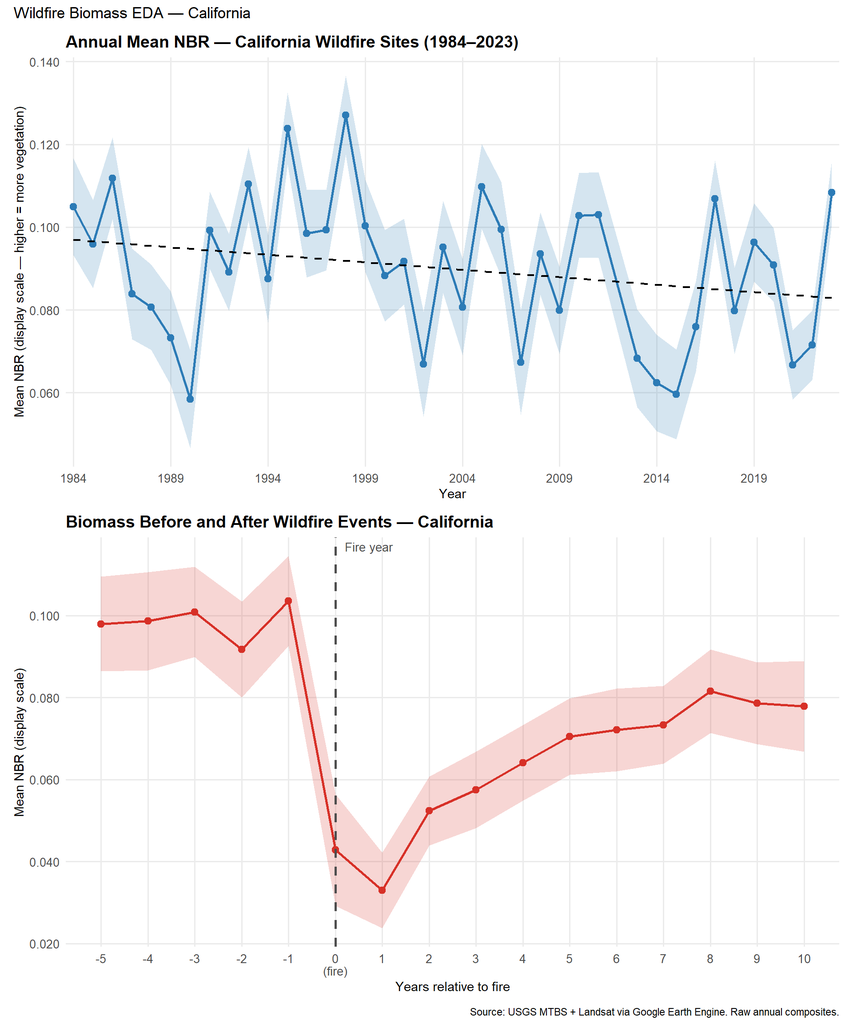

```r
combined <- (p5 + labs(subtitle = NULL, caption = NULL)) /
            (p6 + labs(subtitle = NULL, caption = NULL)) +
  plot_annotation(
    title   = glue("Wildfire Biomass EDA — {STATE_LABEL}"),
    caption = "Source: USGS MTBS + Landsat via Google Earth Engine. Raw annual composites."
  )

print(combined)
```

```r
ggsave(here("figures/biomass_combined.png"),
       plot = combined, width = 10, height = 12, dpi = 300, bg = "white")
```